# solving_exercise

```python
from sklearn.tree import DecisionTreeClassifier, plot_tree
from sklearn.model_selection import train_test_split
from sklearn.metrics import accuracy_score
import matplotlib.pyplot as plt
import seaborn as sns
import pandas as pd
import numpy as np
```

```python
plt.style.use("seaborn-pastel")
```

```python
df = pd.read_csv("diabetes.csv")
```

```python
X = df.loc[:, ~df.columns.isin(["Outcome"])]
y = df["Outcome"]
feature_names = X.columns
```

```python
x_train, x_test, y_train, y_test = train_test_split(X, y, train_size=0.8, random_state=47, stratify=y)
```

# Funções de Ajuda

```python
def get_performance(model, x, y):
    y_pred = model.predict(x)
    return accuracy_score(y, y_pred)
```

```python
def model_train_test(**kwargs):
    params = "\n".join([f"{key}: {val}" for key, val in kwargs.items()])
    model = DecisionTreeClassifier(criterion="gini", **kwargs)
    model.fit(x_train, y_train)
    acc_model = get_performance(model, x_test, y_test)*100
    print("="*50)
    print(params)
    print(f"Accuracy: {acc_model:.2f}%")
    print("="*50)
    return model, acc_model
```

# A)

A árvore treinada não possui limite de profundidade, isto é, crescerá até atingir folhas puras ou com número de observações maior do que min_samples_leaf que neste caso foi escolhido como 1

**OBS: Critério de Gini escolhido**

```python
baseline, acc_baseline = model_train_test(max_depth=None, min_samples_leaf=1)
```

```
==================================================
max_depth: None
min_samples_leaf: 1
Accuracy: 72.73%
==================================================
```

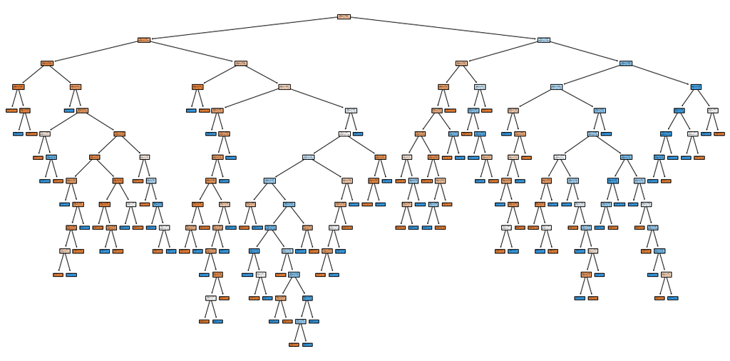

```python
plt.figure(figsize=(20,10))
ax = plot_tree(baseline, filled=True)
```

Reduzindo o tamanho da arvore plotada para melhor visualização

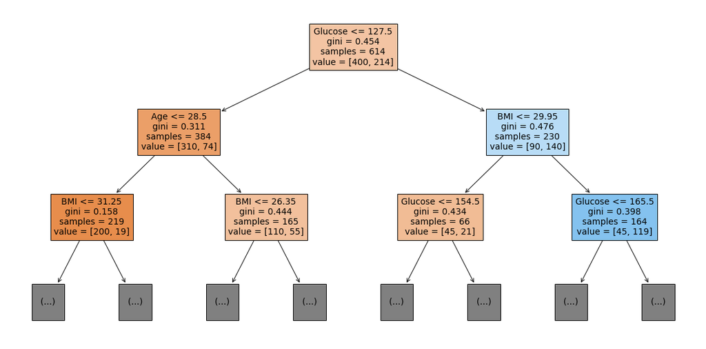

```python
plt.figure(figsize=(20,10))
ax = plot_tree(baseline, filled=True, max_depth=2, feature_names=feature_names)
```

Como as divisões dos nós são feitas baseados no melhor split as variáveis que aparecem nas primeiras etapas de divisão serão as que fornecem mais informação para conseguir realizar a classificação do paciente. Nesse caso, Glucose, BMI (Body mass index) e Age (idade) são as três variáveis com maior influência. Isso pode ser confirmado pelo gráfico abaixo onde é disposto de maneira quantitativa a importância de cada variável

```
<BarContainer object of 8 artists>
```

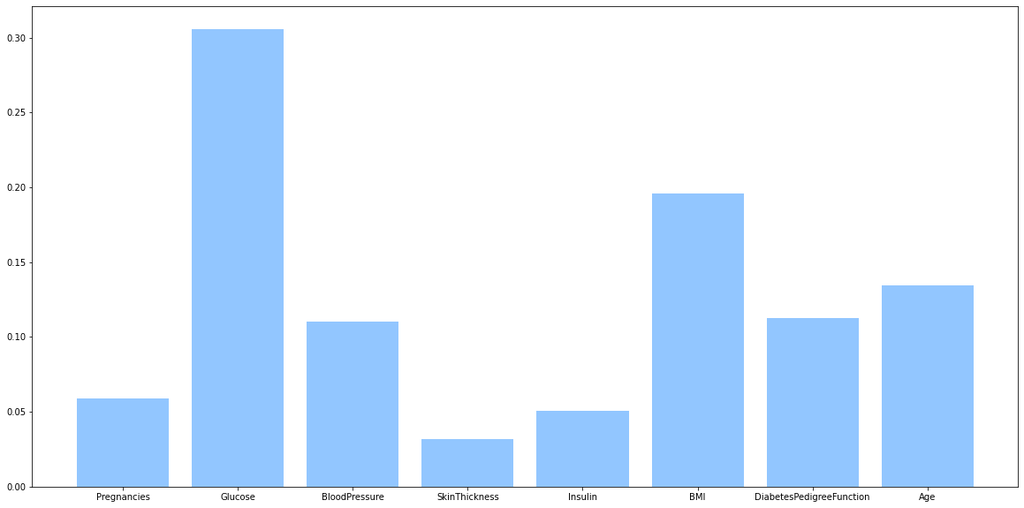

```python
plt.figure(figsize=(20,10))
plt.bar(feature_names, baseline.feature_importances_)
```

# B)

```python
baseline.get_depth()
```

```
14
```

Como o modelo baseline tem arvore de tamanho 14 e a divisão dos nós era feita até obter folhas puras sabe-se que esse tamanho é o maior possível para os dados utilizados, com isso pode-se realizar o plot de uma região para os parâmetros de profundidade da arvore e quantidade de observações nas folhas para avaliar o efeito na acurácia do modelo

```python
max_depth_list= np.arange(1, 15, 1)
min_samples_leaf_list = np.arange(1, 102, 5)
```

```python
XX, YY = np.meshgrid(max_depth_list, min_samples_leaf_list)
```

```python
models = {}
accs = []

for idx, (i, j) in enumerate(zip(XX.ravel(), YY.ravel())):
    print(f"Iteração {idx}")
    mod, acc = model_train_test(max_depth=i, min_samples_leaf=j)
    models[f"max_{i}_min_{j}"] = mod
    accs.append(acc)
```

```
Iteração 0
==================================================
max_depth: 1
min_samples_leaf: 1
Accuracy: 74.68%
==================================================
Iteração 1
==================================================
max_depth: 2
min_samples_leaf: 1
Accuracy: 77.27%
==================================================
Iteração 2
==================================================
max_depth: 3
min_samples_leaf: 1
Accuracy: 77.27%
==================================================
Iteração 3
==================================================
max_depth: 4
min_samples_leaf: 1
Accuracy: 76.62%
==================================================
Iteração 4
==================================================
max_depth: 5
min_samples_leaf: 1
Accuracy: 77.27%
==================================================
Iteração 5
==================================================
max_depth: 6
min_samples_leaf: 1
Accuracy: 77.27%
==================================================
Iteração 6
==================================================
max_depth: 7
min_samples_leaf: 1
```

[output cut: 1709 more lines]

```
min_samples_leaf: 101
Accuracy: 73.38%
==================================================
Iteração 292
==================================================
max_depth: 13
min_samples_leaf: 101
Accuracy: 73.38%
==================================================
Iteração 293
==================================================
max_depth: 14
min_samples_leaf: 101
Accuracy: 73.38%
==================================================
```

```python
accs_array = np.array(accs)
```

```python
accs_array = accs_array.reshape(XX.shape)
```

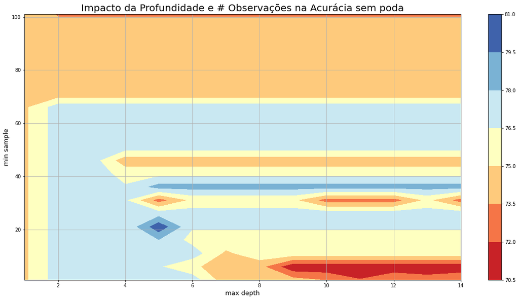

```python
plt.figure(figsize=(20,10))
ax = plt.contourf(XX, YY, accs_array, cmap="RdYlBu")
cbar = plt.colorbar()
plt.xlabel("max depth", fontsize=13)
plt.ylabel("min sample", fontsize=13)
plt.title("Impacto da Profundidade e # Observações na Acurácia sem poda", fontsize=20)
plt.grid()
```

A partir do gráfico acima pode-se fazer 3 observações relevantes sobre o impacto dos hiperparâmetros:

- Na região onde min sample é baixo a geração do conjunto de regras para classificação é dominado pelo argumento da profundidade da árvore. Nos casos onde esse valor é alto obtem-se modelos especializados nos dados de treinamento, visto que são permitidos, pela elevada profundidade, alcançar folhas com elevada pureza. Nos casos onde a profundidade é menor as folhas não possuem pureza elevada devido a profundidade reduzida e a performance do modelo é dependente dos atributos mais relevantes.
- Na região onde min sample é alto temos uma redução do efeito da dominancia do parametro de profundidade devido essa possibilidade de permitir uma maior impureza nas folhas, dessa forma os modelos obtidos nessa região tem uma performance mais homogenea.
- Em regiões em que tanto a max depth e min sample são moderados é onde atingimos os melhores resultados relacionados a performance do nosso modelo, ou seja, onde conseguimos obter uma melhor generalização devido ao uso parcimonioso de min sample e da profundidade.

OBS: Baseline está no ponto (14, 1)

```python
# Ref https://stackoverflow.com/questions/20224526/how-to-extract-the-decision-rules-from-scikit-learn-decision-tree
from sklearn.tree import _tree

def tree_to_code(tree, feature_names):
    tree_ = tree.tree_
    feature_name = [
        feature_names[i] if i != _tree.TREE_UNDEFINED else "undefined!"
        for i in tree_.feature
    ]
    print("def tree({}):".format(", ".join(feature_names)))

    def recurse(node, depth):
        indent = "  " * depth
        if tree_.feature[node] != _tree.TREE_UNDEFINED:
            name = feature_name[node]
            threshold = tree_.threshold[node]
            print("{}if {} <= {}:".format(indent, name, threshold))
            recurse(tree_.children_left[node], depth + 1)
            print("{}else:  # if {} > {}".format(indent, name, threshold))
            recurse(tree_.children_right[node], depth + 1)
        else:
            print("{}return {}".format(indent, tree_.value[node]))

    recurse(0, 1)
```

Exemplo de regra de classificação de uma arvore não tão profunda para conseguirmos ver a estrutura sem mairoes problemas

```python
tree_to_code(models["max_2_min_6"], feature_names)
```

```
def tree(Pregnancies, Glucose, BloodPressure, SkinThickness, Insulin, BMI, DiabetesPedigreeFunction, Age):
  if Glucose <= 127.5:
    if Age <= 28.5:
      return [[200.  19.]]
    else:  # if Age > 28.5
      return [[110.  55.]]
  else:  # if Glucose > 127.5
    if BMI <= 29.949999809265137:
      return [[45. 21.]]
    else:  # if BMI > 29.949999809265137
      return [[ 45. 119.]]
```

# C)

```python
models_prune = {}
accs_prune = []
ccps = np.linspace(0.001, 0.01, 51)

for idx, ccp in enumerate(ccps):
    print(f"Iteração {idx}")
    mod, acc = model_train_test(max_depth=None, min_samples_leaf=1, ccp_alpha=ccp)
    models_prune[f"ccp_{ccp}"] = mod
    accs_prune.append(acc)
```

```
Iteração 0
==================================================
max_depth: None
min_samples_leaf: 1
ccp_alpha: 0.001
Accuracy: 72.08%
==================================================
Iteração 1
==================================================
max_depth: None
min_samples_leaf: 1
ccp_alpha: 0.00118
Accuracy: 72.08%
==================================================
Iteração 2
==================================================
max_depth: None
min_samples_leaf: 1
ccp_alpha: 0.00136
Accuracy: 72.73%
==================================================
Iteração 3
==================================================
max_depth: None
min_samples_leaf: 1
ccp_alpha: 0.0015400000000000001
Accuracy: 74.03%
==================================================
Iteração 4
==================================================
max_depth: None
min_samples_leaf: 1
ccp_alpha: 0.0017200000000000002
Accuracy: 75.97%
==================================================
Iteração 5
==================================================
max_depth: None
min_samples_leaf: 1
ccp_alpha: 0.0019000000000000002
```

[output cut: 302 more lines]

```
==================================================
Iteração 49
==================================================
max_depth: None
min_samples_leaf: 1
ccp_alpha: 0.009819999999999999
Accuracy: 77.27%
==================================================
Iteração 50
==================================================
max_depth: None
min_samples_leaf: 1
ccp_alpha: 0.01
Accuracy: 77.27%
==================================================
```

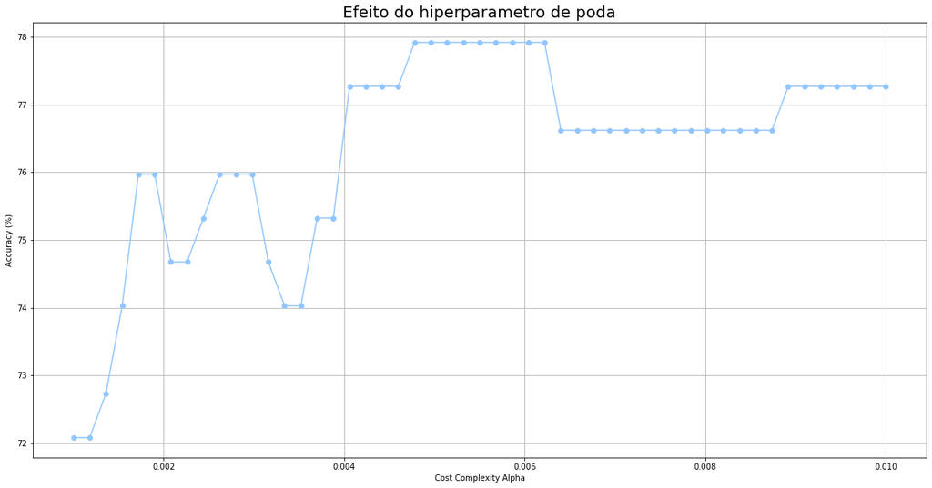

```python
plt.figure(figsize=(20,10))
plt.plot(ccps, accs_prune, '-o')
plt.grid()
plt.xlabel("Cost Complexity Alpha")
plt.ylabel("Accuracy (%)")
plt.title("Efeito do hiperparametro de poda", fontsize=20)
```

O cenário geral utilizando poda parece ter melhorado, visto que o intervalo da acurácia obtido tem um minimo mais elevado. Além disso, olhando no gráfico abaixo pode-se notar que a estrurua da árvore para o modelo baseline com e sem poda são diferentes, sendo a estrutura da arvore com poda bem mais enxuta e utilizando as apenas as variaveis mais significantes (como indificado no item A) e uma performance melhor. Em vista, disso espera-se que a arvore com poda consiga obter uma generalização melhor do que a sem, visto que a poda serve para remover variaveis desnecessarias que possam estar introduzindo apenas ruidos no nosso modelo e fazendo-o se especializar em variações não relevantes à nossa variável de saída.

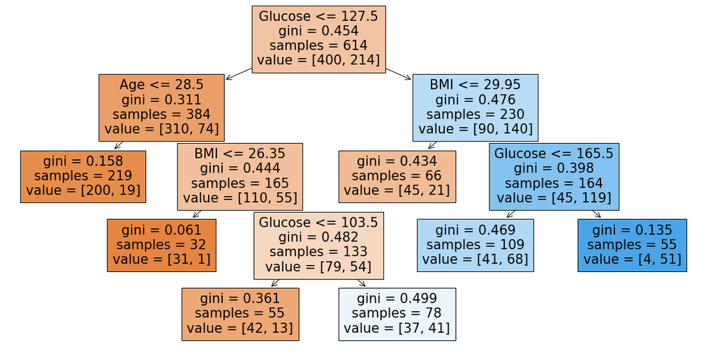

```python
plt.figure(figsize=(20,10))
ax = plot_tree(models_prune["ccp_0.00676"], filled=True, feature_names=feature_names)
```

# D)

## Hiperparemetros

De acordo com Item B) e C) os melhores hiperparemetros seriam

```python
def model_train_test_modified(**kwargs):
    seed = np.random.randint(0,1e4)
    x_train, x_test, y_train, y_test = train_test_split(X, y, train_size=0.8, random_state=seed, stratify=y)
    params = "\n".join([f"{key}: {val}" for key, val in kwargs.items()])
    model = DecisionTreeClassifier(criterion="gini", **kwargs)
    model.fit(x_train, y_train)
    acc_model = get_performance(model, x_test, y_test)*100
    print("="*50)
    print(params)
    print(f"Accuracy: {acc_model:.2f}%")
    print("="*50)
    return model, acc_model
```

```python
models_final = []
accs_final = []
for i in range(10):
    model, acc = model_train_test_modified(max_depth=5, min_samples_leaf=20, ccp_alpha=0.005)
    models_final.append(model)
    accs_final.append(acc)
```

```
==================================================
max_depth: 5
min_samples_leaf: 20
ccp_alpha: 0.005
Accuracy: 70.78%
==================================================
==================================================
max_depth: 5
min_samples_leaf: 20
ccp_alpha: 0.005
Accuracy: 76.62%
==================================================
==================================================
max_depth: 5
min_samples_leaf: 20
ccp_alpha: 0.005
Accuracy: 77.92%
==================================================
==================================================
max_depth: 5
min_samples_leaf: 20
ccp_alpha: 0.005
Accuracy: 75.97%
==================================================
==================================================
max_depth: 5
min_samples_leaf: 20
ccp_alpha: 0.005
Accuracy: 79.87%
==================================================
==================================================
max_depth: 5
min_samples_leaf: 20
ccp_alpha: 0.005
Accuracy: 81.17%
==================================================
==================================================
max_depth: 5
min_samples_leaf: 20
ccp_alpha: 0.005
Accuracy: 75.97%
==================================================
==================================================
max_depth: 5
min_samples_leaf: 20
ccp_alpha: 0.005
Accuracy: 75.32%
==================================================
==================================================
max_depth: 5
min_samples_leaf: 20
ccp_alpha: 0.005
Accuracy: 75.97%
==================================================
==================================================
max_depth: 5
min_samples_leaf: 20
ccp_alpha: 0.005
Accuracy: 75.32%
==================================================
```

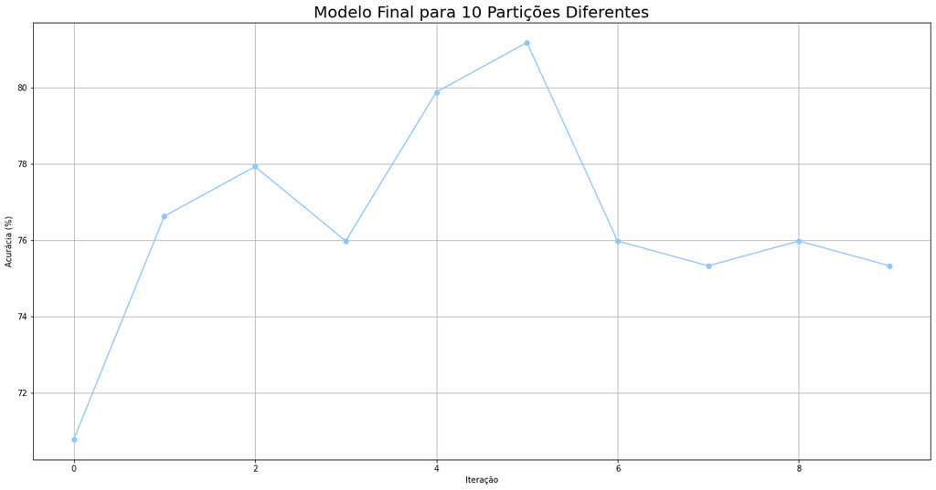

```python
plt.figure(figsize=(20,10))
plt.plot(accs_final, '-o')
plt.xlabel("Iteração")
plt.ylabel("Acurácia (%)")
plt.title("Modelo Final para 10 Partições Diferentes", fontsize=20)
plt.grid()
```

Visualizando arvore 0 e arvore 5 dado que são as arvores com maior diferença de performance

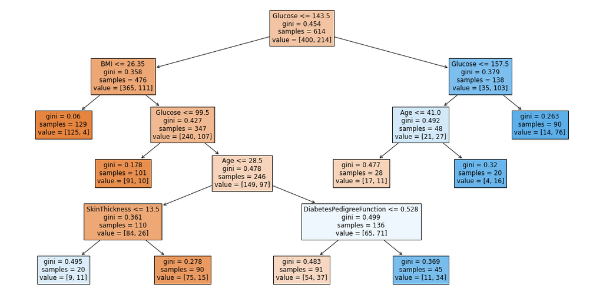

```python
plt.figure(figsize=(20,10))
ax = plot_tree(models_final[0], filled=True, feature_names=feature_names)
```

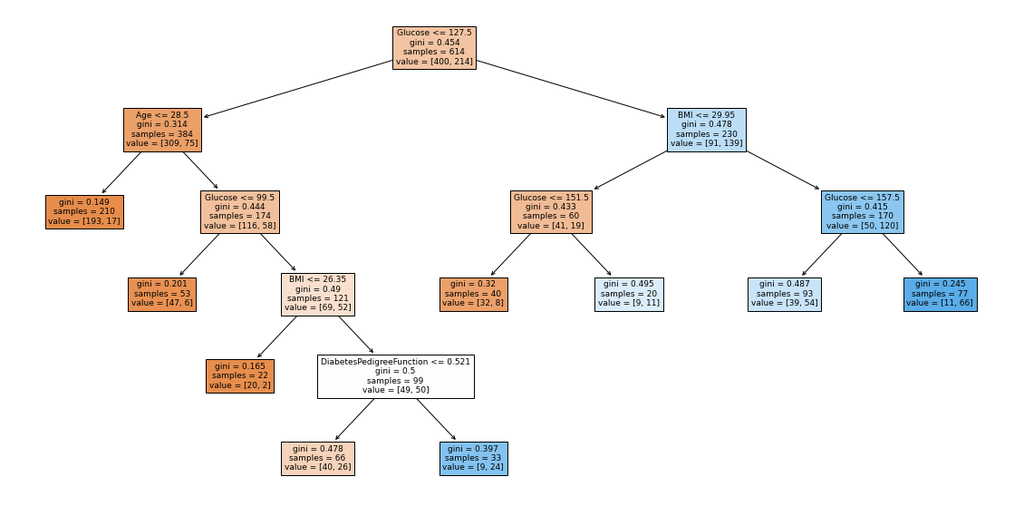

```python
plt.figure(figsize=(20,10))
ax = plot_tree(models_final[5], filled=True, feature_names=feature_names)
```